# Cleaning and Exploratory data analysis of Text Corpora

Gaurav

28 November 2016

# 1. Summary

The project analyses text corpus called HC Corpora. The Data is available in English, German, Finnish and Russian language. The Project analyses English language corpora only. The corpora are collected from publicly available sources by a web crawler like news, blogs and twitter. Reproducible scripts is written to sample the data and then clean it. Removing numbers, punctuation, extra white spaces, profanity filtering id done and this data is saved. Finally exploratory data analysis is performed. *We find highest **317** frequent words cover 50% of all word instances in the language.*

Scripts is reproducible

# 2. Getting the Data

The Dataset is downloaded from coursera and extracted.

```r
if(!file.exists("./dataset")){
    dir.create("./dataset");
    dir.create("./dataset/raw");
    fileUrl <- "https://d396qusza40orc.cloudfront.net/dsscapstone/dataset/Coursera-SwiftKey.zip";
    download.file(fileUrl,destfile="./dataset/raw/Dataset.zip");
    # Unzip dataSet to /dataset/raw directory
    unzip(zipfile="./dataset/raw/Dataset.zip",exdir="./dataset/raw");
}
```

### Analysing Raw Data

The Downloaded Data contains directories for languages - English, Russian, Finnish and German. In each directory there are 3 files. This data is crawled from news, blogs and twitter. The project analyses data in English language only.

```r
files <- list.files("./dataset/raw/final/en_US");
sizeMb <- file.info(list.files("./dataset/raw/final/en_US", full.names = T))[,1]/(2^20);
lines <- c(length(readLines("./dataset/raw/final/en_US/en_US.blogs.txt")),length(readLines("./dataset/raw/final/en_US/en_US.news.txt")),length(readLines("./dataset/raw/final/en_US/en_US.twitter.txt")));
dfRaw <- data.frame(files, sizeMb, lines);
dfRaw
```

```
##               files   sizeMb   lines
## 1   en_US.blogs.txt 200.4242  899288
## 2    en_US.news.txt 196.2775 1010242
## 3 en_US.twitter.txt 159.3641 2360148
```

Twitter data size is small but it contains highest number of lines. Contents of twitter file.

```r
readLines("./dataset/raw/final/en_US/en_US.twitter.txt")[1:5]
```

```
## [1] "How are you? Btw thanks for the RT. You gonna be in DC anytime soon? Love to see you. Been way, way too long."
## [2] "When you meet someone special... you'll know. Your heart will beat more rapidly and you'll smile for no reason."
## [3] "they've decided its more fun if I don't."
## [4] "So Tired D; Played Lazer Tag & Ran A LOT D; Ughh Going To Sleep Like In 5 Minutes ;)"
## [5] "Words from a complete stranger! Made my birthday even better :)"
```

We can see the data is not in desired form. Data contains numbers, punctuation, extra white spaces, words of offensive and profane meaning. We need to do necessary cleaning on data.

# 3. Sampling

Before cleaning we need to do sampling as the data is huge. Often relatively few randomly selected rows or chunks need to be included to get an accurate *approximation* to results that would be obtained using all the data. We created a separate sub-sample dataset in “sampled” directory by reading in a random subset of the original data and writing it out to a separate file.

We sampled **1%** of raw data and saved it “sampled” directory

```r
## Sampling Dataset
if(!file.exists("./dataset/sampled")){
    sourceDir <- "./dataset/raw/final";
    destDir <- "./dataset/sampled"
    dir.create(destDir);
    newdirectories <- list.files(sourceDir);
    for (dir in newdirectories){
        newDir <- paste(destDir, dir, sep = "/");
        dir.create(newDir);
        files <- list.files(paste(sourceDir, dir, sep = "/"));
        for(file in files){
            sourceFile <- paste(sourceDir, dir, file, sep = "/");
            destFile <- paste(destDir, dir, file, sep = "/");

            fl <- readLines(sourceFile);
            sampleVector <- rbinom(length(fl), 1, 0.01);
            sampleFl <- fl[sampleVector == 1];
            fileConn<-file(destFile);
            writeLines(sampleFl, fileConn);
            close(fileConn);
            rm(fl,sampleFl)
            gc();
        }
    }
    ## removing all the variables  to free up memory
    rm(list = ls())
    ## forcefully calling garbage collector
    gc();
}
```

### Analysing Sampled Data

After sampling we see the file sizes and number of lines of sampled data.

```r
files <- list.files("./dataset/sampled/en_US/");
sizeMb <- file.info(list.files("./dataset/sampled/en_US/", full.names = T))[,1]/(2^20);
lines <- c(length(readLines("./dataset/sampled/en_US/en_US.blogs.txt")),length(readLines("./dataset/sampled/en_US/en_US.news.txt")),length(readLines("./dataset/sampled/en_US/en_US.twitter.txt")));
dfSampled <- data.frame(files, sizeMb, lines);
dfSampled
```

```
##               files   sizeMb lines
## 1   en_US.blogs.txt 2.023852  9100
## 2    en_US.news.txt 1.925761  9983
## 3 en_US.twitter.txt 1.575420 23660
```

We can see size of files and line counts are almost 1% of the raw data. This representative sample can be used to infer facts about raw data. **We will be performing cleaning on this sampled data.**

# 4. Cleaning

Next step is to clean sampled data. We store it in “clean” directory. Cleaning procedure is as follows.

### 1. Lowring the words

This is required because words like “this” and “This” should be considered same.

### 2. Replace puctuations like - and : with space

There are many phrases in corpora like “24-years-old”. If we remove “-” directly, “24yearsold” wouldn’t make any sense. So here we are replacing “-” with space so phase would become “24 years old”

### 3. Removing numbers with apostrophe S (’s)

Phrases like 90’s, 80’s, if we remove numbers and punctuation we will be left with single character s, which is not desirable, So in this step we remove all these types of terms.

### 4. Removing numbers

In this step we remove all occurrences of numbers in dataset

### 5. Profanity Filtering

The project filters the obscene words using [obscene word list by LDNOOBW on github.](https://github.com/LDNOOBW/List-of-Dirty-Naughty-Obscene-and-Otherwise-Bad-Words)

### 6. Profanity Filtering Continued

There are still obscene words which are masked and not identified by above step. eg. words like “sh*t"

### 7. Removing Punctuations except ’ apostrophe

This step will remove all punctuation **except ’ apostrophe**. Because this is frequently used in writing like “that’s”, “it’s”, “here’s”. Removing it might not be a good idea.

### 8. Removing Non-english words

This step will remove words which are non-English. i.e. which are foreign language words.

### 9. Removing Extra whitespaces

This step will remove extra white spaces.

Reproducible script is written which performs all this steps on sampled data and stores it in “clean” directory.

**We will be performing further analysis on this cleaned data.**

```r
if(!file.exists("./dataset/clean/")){
    dir.create("./dataset/clean/en_US", recursive = T)
    library(tm);
    sourceDir <- "./dataset/sampled/en_US"
    sourceFile <- "./dataset/sampled/en_US/en_US.blogs.txt"

    ## reading the sampled corpus
    docs <- Corpus(DirSource(sourceDir));

    ## lowering the alphabets
    docs <- tm_map(docs , content_transformer(tolower));

    ## remove puctuations like - and : with space
    ## eg. for 24-year-old like phrases
    toSpace <- content_transformer(function(x, pattern) {return (gsub(pattern, " ", x))})
    docs <- tm_map(docs, toSpace, "-")
    docs <- tm_map(docs, toSpace, ":")

    ## removing numbers with apostrophe s
    ## eg. 20's 90's like tokens
    docs <- tm_map(docs, toSpace, "[0-9]+'s")

    ## remove numbers
    docs <- tm_map(docs , removeNumbers)

    ## profanity filtering
    badwords <- readLines("profanity filtering.txt")
    badwords <- paste(badwords,collapse ="|")
    removeBadWords <- content_transformer(function(x, pattern) {return (gsub(pattern, "*", x))})
    docs <- tm_map(docs, removeBadWords, badwords);

    ## remove words like sh*t
    removeStaredBadWords <- content_transformer(function(x, pattern) {return (gsub(pattern, "", x))})
    docs <- tm_map(docs, removeStaredBadWords, "[a-z]+\\*+[a-z]+");

    ## remove punctuations without apostrophe
    removePunctWithoutApostrophe <- content_transformer(function(x, pattern) {return (gsub(pattern, "", x))})
    docs <- tm_map(docs, removePunctWithoutApostrophe, "[^[:alnum:][:space:]']");

    ## remove non-english words
    removeNonEnglishWords <- content_transformer(function(x, pattern) {return (gsub(pattern, "", x))})
    docs <- tm_map(docs, removeNonEnglishWords, "[^0-9A-Za-z///' ]");

    ## remove extra white spaces
    docs <- tm_map(docs , stripWhitespace)

    writeCorpus(x = docs,path = "dataset/clean/en_US/",filenames = paste(names(docs), sep = ""))
    rm(list = ls())
    gc();
}
```

Contents of twitter file.

```r
readLines("./dataset/clean/en_US/en_US.twitter.txt")[1:5]
```

```
## [1] "i know i know then you kick yourself when the fight goes lopsided but if the upset does happen wow nothing like it"
## [2] "me too"
## [3] " sounds good bro"
## [4] " motivation and inspiration energize people not by pushing them in the right direction as control mechanisms do but by satisfying basic"
## [5] "i love talking to this kidd"
```

We can see the data is in desired form. ’ is frequently used in writing like “that’s”, “it’s”, “here’s”. Removing it might not be a good idea.

# 5. Exploratory Data Analysis

Finally we are performing exploratory data analysis on clean data. Lets have a look at file sizes and line counts

```r
files <- list.files("./dataset/clean/en_US/");
sizeMb <- file.info(list.files("./dataset/clean/en_US/", full.names = T))[,1]/(2^20);
lines <- c(length(readLines("./dataset/clean/en_US/en_US.blogs.txt")),length(readLines("./dataset/clean/en_US/en_US.news.txt")),length(readLines("./dataset/clean/en_US/en_US.twitter.txt")));
dfCleaned <- data.frame(files, sizeMb, lines);
dfCleaned
```

```
##               files   sizeMb lines
## 1   en_US.blogs.txt 1.925802  9100
## 2    en_US.news.txt 1.821692  9983
## 3 en_US.twitter.txt 1.477024 23660
```

Loading tm library and relevant libraries. Creating Corpus and DocumentTermMatrix

```r
library(tm)
library(ggplot2)
library(dplyr)
library(wordcloud)
sourceDir <- "./dataset/clean/en_US/"

corp <- Corpus(DirSource(sourceDir))
dtm <- DocumentTermMatrix(corp)
```

## Document Term Matrix Analysis

```r
dtm
```

```
## <<DocumentTermMatrix (documents: 3, terms: 53865)>>
## Non-/sparse entries: 82524/79071
## Sparsity           : 49%
## Maximal term length: 98
## Weighting          : term frequency (tf)
```

In Document Term Matrix we have documents along the rows and terms along the columns. We see there are 3 documents and **53865** unique terms in data. Sparsity is **49%** which is quite high. In Document Term Matrix we have around 79071 entries zero. Which signifies there are many terms which occurs very few times (1 or 2 times) in corpora. Maximal term length is 98. We can remove the sparsity.

```r
removeSparseTerms(x = dtm, sparse = .6)
```

```
## <<DocumentTermMatrix (documents: 3, terms: 18972)>>
## Non-/sparse entries: 47631/9285
## Sparsity           : 16%
## Maximal term length: 18
## Weighting          : term frequency (tf)
```

Here We are removing terms which occurs only in 1 document. You can see the result. Unique terms dropped to **18972** and sparsity dropped to **16%**. These are the terms which occur frequently in the data. This is just for demonstration purpose.

## Word counts by document

```r
mat <- as.matrix(dtm)
wordCount <- rowSums(mat)
wordCount
```

```
##   en_US.blogs.txt    en_US.news.txt en_US.twitter.txt
##            292457            271629            227594
```

## Word Frequency Analysis

Now we are forming dataframe from DocumentTermMatrix on which it is easy to do transformations. Printing top 10 highest frequent words in dataset

```r
mat <- as.matrix(dtm)
freq <- colSums(mat)
df <- data.frame(word <- names(freq), freq <- freq)
colnames(df) <- c("word", "freq")
rownames(df)<- NULL
df <- arrange(df, desc(freq))
head(df, 10)
```

```
##    word  freq
## 1   the 47667
## 2   and 24127
## 3   for 10956
## 4  that 10272
## 5   you  9453
## 6  with  7104
## 7   was  6187
## 8  this  5326
## 9  have  5242
## 10  are  4969
```

```r
tail(df,10)
```

```
##             word freq
## 53856       zune    1
## 53857     zunino    1
## 53858     zurich    1
## 53859       zuzu    1
## 53860      zuzus    1
## 53861      zwick    1
## 53862 zygarewicz    1
## 53863       zygi    1
## 53864  zygomatic    1
## 53865    zynga's    1
```

Shows high frequent and low frequent words in datasets.

Now we see frequency wise sorted words which covers percentage wise instances of all word instances in the language, Cumulative percentages are also showed

```r
## indexing by frequency
df <- mutate(df, index = 1:length(word))
## frequency percent
df <- mutate(df, percent = (freq/(sum(freq)))*100)
## frequency percent cumulative
df <- mutate(df, cumPercent = ave(percent, FUN = cumsum))
head(df, 10)
```

```
##    word  freq index   percent cumPercent
## 1   the 47667     1 6.0209933   6.020993
## 2   and 24127     2 3.0475697   9.068563
## 3   for 10956     3 1.3838925  10.452456
## 4  that 10272     4 1.2974939  11.749949
## 5   you  9453     5 1.1940430  12.943993
## 6  with  7104     6 0.8973323  13.841325
## 7   was  6187     7 0.7815026  14.622827
## 8  this  5326     8 0.6727466  15.295574
## 9  have  5242     9 0.6621362  15.957710
## 10  are  4969    10 0.6276526  16.585363
```

We see that top **10 words covers almost 16% of all instances** of text data. **Which is quite amazing.**

Number Of words that covers 50% of instances

```r
filter(df,cumPercent>50)[1,]
```

```
##     word freq index    percent cumPercent
## 1 course  296   317 0.03738884   50.00859
```

We see that top **317** high frequent words covers **50%** of all instances in data out of all **53865** unique words

Number of words that covers 90% of instances

```r
filter(df,cumPercent>90)[1,]
```

```
##   word freq index      percent cumPercent
## 1  ol'    7  9338 0.0008841956   90.00051
```

We see that top **9338** high frequent words covers **90%** of all instances in data out of all **53865** unique words. Which is amazing.

## WordCloud

Wordcloud of **top 150 words** after removing top 5 high frequent words, **“the, and, for, that, you”**, as they causes skewness in plot.

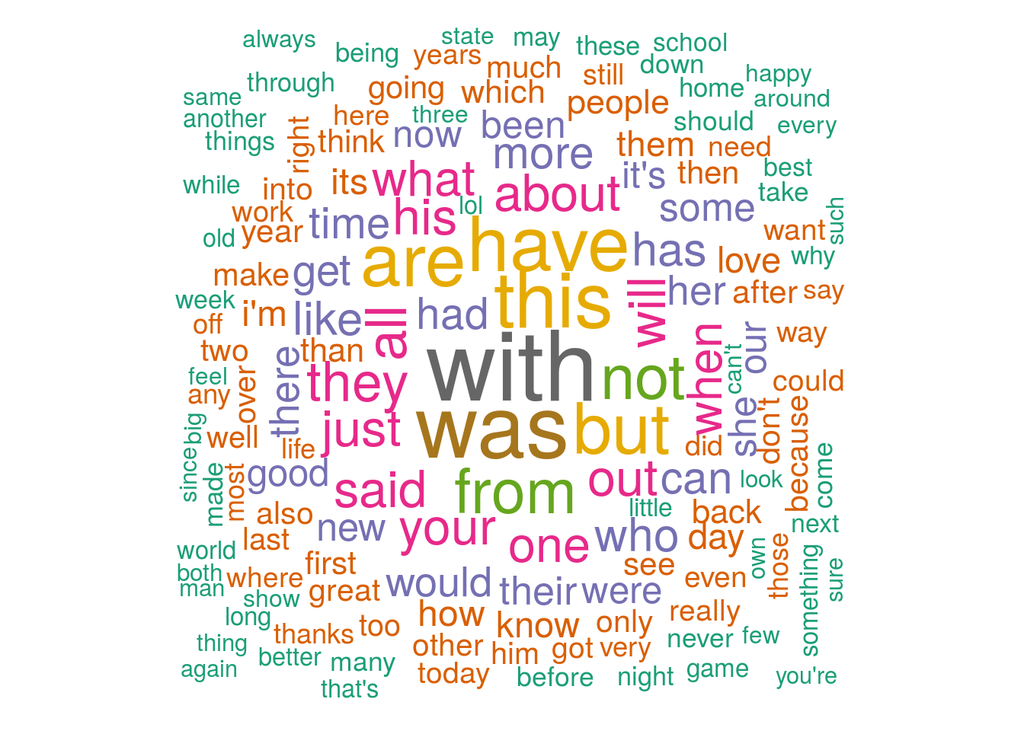

```r
## wordcloud
wordcloud(words = df$word[-(1:5)], freq = df$freq[-(1:5)], min.freq = 10,
          max.words=150, random.order=FALSE, scale = c(4,0.7), rot.per = 0.20,
          colors=brewer.pal(8, "Dark2"))
```

## Plot

Barplot of top 20 highest frequent words

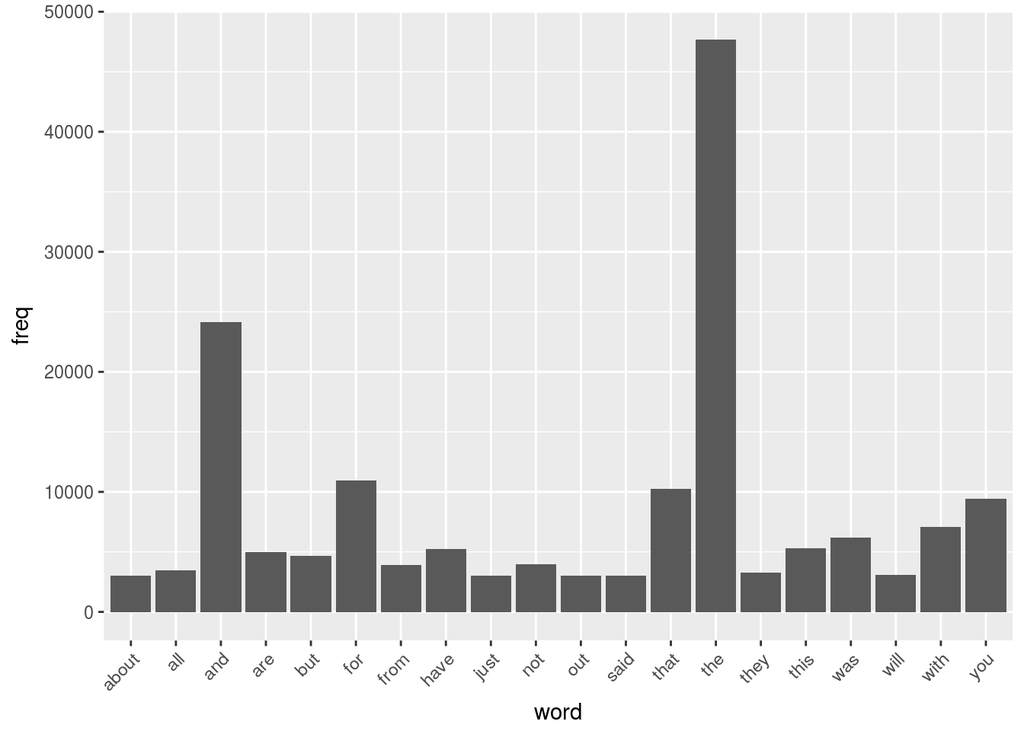

```r
p <- ggplot(df[1:20,], aes(word, freq))
p <- p + geom_bar(stat="identity")
p <- p + theme(axis.text.x=element_text(angle=45, hjust=1))
p
```

# 6. Tokenization

We will create tokens of 2 words 2-gram, tokens of 3 words 3-grams, and find the frequencies of them. Word pairs are sorted in descending order of Frequencies.

## 1. Frequencies of 2-grams

```r
BigramTokenizer <- function(x){
    unlist(lapply(ngrams(words(x), 2), paste, collapse = " "), use.names = FALSE)
}

dtmBi <- DocumentTermMatrix(corp, control = list(tokenize = BigramTokenizer))
matBi <- as.matrix(dtmBi)
freqBi <- colSums(matBi)
dfBi <- data.frame(word <- names(freqBi), freq <- freqBi)
colnames(dfBi) <- c("word pairs", "freq")
rownames(dfBi)<- NULL
dfBi <- arrange(dfBi, desc(freq))
head(dfBi, 10)
```

```
##    word pairs freq
## 1      of the 4377
## 2      in the 4053
## 3      to the 2126
## 4     for the 2033
## 5      on the 2025
## 6       to be 1679
## 7      at the 1398
## 8     and the 1271
## 9        in a 1219
## 10   with the 1053
```

## 2. Frequencies of 3-grams

```r
TrigramTokenizer <-function(x){
    unlist(lapply(ngrams(words(x), 3), paste, collapse = " "), use.names = FALSE)
}

dtmTri <- DocumentTermMatrix(corp, control = list(tokenize = TrigramTokenizer))
matTri <- as.matrix(dtmTri)
freqTri <- colSums(matTri)
dfTri <- data.frame(word <- names(freqTri), freq <- freqTri)
colnames(dfTri) <- c("word pairs", "freq")
rownames(dfTri)<- NULL
dfTri <- arrange(dfTri, desc(freq))
head(dfTri, 10)
```

```
##        word pairs freq
## 1      one of the  324
## 2        a lot of  304
## 3  thanks for the  239
## 4         to be a  207
## 5     going to be  185
## 6      the end of  151
## 7      as well as  148
## 8       i want to  147
## 9        it was a  144
## 10    some of the  136
```

As we move from 2-gram to 3-gram, 3-gram to 4-gram, accuracy increases but at the cost of speed and performance. We Have to find perfect balance between accuray ~ speed in n-gram model. Which we will be doing in upcoming sessions.

# 7. Prediction Algorithm

Prediction algorithm will be n-gram. We will find the occurrences of words paired in 2 groups, 3 groups, 4 groups in the corpora. Then find the frequencies of these groups, through which we will get the probability of next word.

We will analyse the accuracy and speed of 2-gram, 3gram, 4-gram. Then we will choose algorithm which gives good speed with good accuracy.

# 8. Shiny App

App will consists of a text area, below text area there will be 3 suggested word predictions. As soon as couple of words are typed in text area, 3 suggestions will show up. Middle one will be top suggestion. There will be buttons above these suggestions, when clicked content will be entered in text area. Shortcut keys will be assigned to these buttons to speed up typing. Lets see if we can enter on commercial level with this app..!!